Transfer of clinically relevant gene expression signatures in breast cancer: from Affymetrix microarray to Illumina RNA-Sequencing technology

Sociology and Social Research, UniTN  
*Course:* Advanced Data Analysis (in Biology) [146044] - Final Project

Vasily Khodakovsky

# Packages

```r
library(ggplot2)
library(stringr)
library(tidyverse)
library(edgeR)
library(biomaRt)
library(hgu133a.db)
library(GEOquery)
library(ROCR)
library(ALL)
library(dplyr)
library(randomForest)
library(RColorBrewer)
library(genefilter)
library(useful)
library(MASS)
library(pROC)
library(caret)
library(e1071)
library(igraph)
library(rScudo)
library(glmnet)
library(cluster)
library(factoextra)
library(gprofiler2)
library(KEGGREST)
library(KEGGgraph)
library(AnnotationDbi)
library(org.Hs.eg.db)
```

# Data

Fumagalli D, Blanchet-Cohen A, Brown D, Desmedt C et al. Transfer of clinically relevant gene expression signatures in breast cancer: from Affymetrix microarray to Illumina RNA-Sequencing technology. BMC Genomics 2014 Nov 21;15:1008. PMID: 25412710. Fumagalli D, Gacquer D, Rothé F, Lefort A et al. Principles Governing A-to-I RNA Editing in the Breast Cancer Transcriptome. Cell Rep 2015 Oct 13;13(2):277-89. PMID: 26440892  
Link: https://www.ncbi.nlm.nih.gov/geo/query/acc.cgi?acc%20=%20GSE43358

```r
set.seed(1)

gse <- getGEO('GSE43358', destdir = '.', getGPL = FALSE)
gse <- gse[[1]]

summary(gse)
```

```
##        Length         Class          Mode
##             1 ExpressionSet            S4
```

```r
ex <- exprs(gse)
ex2 <- log2(ex)

dim(ex)
```

```
## [1] 54675    57
```

Number of genes: 54675.

Number of samples: 57.

```r
colnames(ex)
```

```
##  [1] "GSM1060909" "GSM1060910" "GSM1060911" "GSM1060912" "GSM1060913"
##  [6] "GSM1060914" "GSM1060915" "GSM1060916" "GSM1060917" "GSM1060918"
## [11] "GSM1060919" "GSM1060920" "GSM1060921" "GSM1060922" "GSM1060923"
## [16] "GSM1060924" "GSM1060925" "GSM1060926" "GSM1060927" "GSM1060928"
## [21] "GSM1060929" "GSM1060930" "GSM1060931" "GSM1060932" "GSM1060933"
## [26] "GSM1060934" "GSM1060936" "GSM1060937" "GSM1060938" "GSM1060939"
## [31] "GSM1060940" "GSM1060941" "GSM1060942" "GSM1060943" "GSM1060944"
## [36] "GSM1060945" "GSM1060946" "GSM1060947" "GSM1060948" "GSM1060949"
## [41] "GSM1060950" "GSM1060951" "GSM1060952" "GSM1060953" "GSM1060954"
## [46] "GSM1060955" "GSM1060956" "GSM1060957" "GSM1060958" "GSM1060959"
## [51] "GSM1060960" "GSM1060961" "GSM1060962" "GSM1060963" "GSM1060964"
## [56] "GSM1060965" "GSM1060966"
```

#### Summary:

```r
summary(ex)
```

```
##    GSM1060909       GSM1060910       GSM1060911       GSM1060912
##  Min.   : 2.683   Min.   : 2.649   Min.   : 2.696   Min.   : 2.627
##  1st Qu.: 4.077   1st Qu.: 4.097   1st Qu.: 4.038   1st Qu.: 4.064
##  Median : 5.196   Median : 5.234   Median : 5.206   Median : 5.207
##  Mean   : 5.748   Mean   : 5.729   Mean   : 5.762   Mean   : 5.758
##  3rd Qu.: 7.114   3rd Qu.: 7.022   3rd Qu.: 7.195   3rd Qu.: 7.142
##  Max.   :14.306   Max.   :14.429   Max.   :14.437   Max.   :14.420
##    GSM1060913       GSM1060914       GSM1060915       GSM1060916
##  Min.   : 2.741   Min.   : 2.688   Min.   : 2.679   Min.   : 2.680
##  1st Qu.: 4.081   1st Qu.: 4.107   1st Qu.: 4.076   1st Qu.: 4.081
##  Median : 5.170   Median : 5.185   Median : 5.124   Median : 5.199
##  Mean   : 5.731   Mean   : 5.676   Mean   : 5.695   Mean   : 5.747
##  3rd Qu.: 7.056   3rd Qu.: 6.895   3rd Qu.: 6.981   3rd Qu.: 7.096
##  Max.   :14.412   Max.   :14.366   Max.   :14.155   Max.   :14.467
##    GSM1060917       GSM1060918       GSM1060919       GSM1060920
##  Min.   : 2.679   Min.   : 2.646   Min.   : 2.689   Min.   : 2.681
##  1st Qu.: 4.079   1st Qu.: 4.069   1st Qu.: 4.094   1st Qu.: 4.076
##  Median : 5.201   Median : 5.157   Median : 5.184   Median : 5.195
##  Mean   : 5.747   Mean   : 5.735   Mean   : 5.718   Mean   : 5.723
##  3rd Qu.: 7.105   3rd Qu.: 7.088   3rd Qu.: 7.003   3rd Qu.: 7.043
##  Max.   :14.448   Max.   :14.338   Max.   :14.260   Max.   :14.468
##    GSM1060921       GSM1060922       GSM1060923       GSM1060924
##  Min.   : 2.728   Min.   : 2.708   Min.   : 2.711   Min.   : 2.717
##  1st Qu.: 4.071   1st Qu.: 4.083   1st Qu.: 4.105   1st Qu.: 4.080
##  Median : 5.161   Median : 5.201   Median : 5.211   Median : 5.250
##  Mean   : 5.738   Mean   : 5.724   Mean   : 5.738   Mean   : 5.756
##  3rd Qu.: 7.111   3rd Qu.: 7.027   3rd Qu.: 7.046   3rd Qu.: 7.116
##  Max.   :14.277   Max.   :14.459   Max.   :14.463   Max.   :14.504
##    GSM1060925       GSM1060926       GSM1060927       GSM1060928
##  Min.   : 2.696   Min.   : 2.661   Min.   : 2.694   Min.   : 2.749
##  1st Qu.: 4.089   1st Qu.: 4.083   1st Qu.: 4.090   1st Qu.: 4.088
##  Median : 5.234   Median : 5.215   Median : 5.202   Median : 5.219
##  Mean   : 5.752   Mean   : 5.744   Mean   : 5.760   Mean   : 5.764
##  3rd Qu.: 7.114   3rd Qu.: 7.099   3rd Qu.: 7.122   3rd Qu.: 7.135
##  Max.   :14.516   Max.   :14.504   Max.   :14.472   Max.   :14.511
##    GSM1060929       GSM1060930       GSM1060931       GSM1060932
##  Min.   : 2.700   Min.   : 2.722   Min.   : 2.726   Min.   : 2.597
##  1st Qu.: 4.094   1st Qu.: 4.090   1st Qu.: 4.074   1st Qu.: 4.069
##  Median : 5.209   Median : 5.198   Median : 5.213   Median : 5.205
##  Mean   : 5.746   Mean   : 5.728   Mean   : 5.750   Mean   : 5.745
```

[output cut: 50 more lines]

```
##  Max.   :14.798   Max.   :14.308   Max.   :14.377   Max.   :14.524
##    GSM1060962       GSM1060963       GSM1060964       GSM1060965
##  Min.   : 2.729   Min.   : 2.672   Min.   : 2.690   Min.   : 2.683
##  1st Qu.: 4.087   1st Qu.: 4.066   1st Qu.: 4.072   1st Qu.: 4.082
##  Median : 5.183   Median : 5.225   Median : 5.199   Median : 5.199
##  Mean   : 5.725   Mean   : 5.750   Mean   : 5.746   Mean   : 5.733
##  3rd Qu.: 7.050   3rd Qu.: 7.133   3rd Qu.: 7.108   3rd Qu.: 7.070
##  Max.   :14.397   Max.   :14.525   Max.   :14.462   Max.   :14.456
##    GSM1060966
##  Min.   : 2.738
##  1st Qu.: 4.087
##  Median : 5.200
##  Mean   : 5.735
##  3rd Qu.: 7.070
##  Max.   :14.145
```

```r
summary(ex2)
```

```
##    GSM1060909      GSM1060910      GSM1060911      GSM1060912
##  Min.   :1.424   Min.   :1.406   Min.   :1.431   Min.   :1.394
##  1st Qu.:2.027   1st Qu.:2.035   1st Qu.:2.014   1st Qu.:2.023
##  Median :2.377   Median :2.388   Median :2.380   Median :2.380
##  Mean   :2.434   Mean   :2.432   Mean   :2.436   Mean   :2.435
##  3rd Qu.:2.831   3rd Qu.:2.812   3rd Qu.:2.847   3rd Qu.:2.836
##  Max.   :3.839   Max.   :3.851   Max.   :3.852   Max.   :3.850
##    GSM1060913      GSM1060914      GSM1060915      GSM1060916
##  Min.   :1.455   Min.   :1.427   Min.   :1.421   Min.   :1.422
##  1st Qu.:2.029   1st Qu.:2.038   1st Qu.:2.027   1st Qu.:2.029
##  Median :2.370   Median :2.374   Median :2.357   Median :2.378
##  Mean   :2.431   Mean   :2.422   Mean   :2.423   Mean   :2.434
##  3rd Qu.:2.819   3rd Qu.:2.785   3rd Qu.:2.804   3rd Qu.:2.827
##  Max.   :3.849   Max.   :3.845   Max.   :3.823   Max.   :3.855
##    GSM1060917      GSM1060918      GSM1060919      GSM1060920
##  Min.   :1.422   Min.   :1.404   Min.   :1.427   Min.   :1.423
##  1st Qu.:2.028   1st Qu.:2.025   1st Qu.:2.034   1st Qu.:2.027
##  Median :2.379   Median :2.366   Median :2.374   Median :2.377
##  Mean   :2.433   Mean   :2.430   Mean   :2.428   Mean   :2.429
##  3rd Qu.:2.829   3rd Qu.:2.825   3rd Qu.:2.808   3rd Qu.:2.816
##  Max.   :3.853   Max.   :3.842   Max.   :3.834   Max.   :3.855
##    GSM1060921      GSM1060922      GSM1060923      GSM1060924
##  Min.   :1.448   Min.   :1.437   Min.   :1.439   Min.   :1.442
##  1st Qu.:2.026   1st Qu.:2.030   1st Qu.:2.037   1st Qu.:2.029
##  Median :2.368   Median :2.379   Median :2.382   Median :2.392
##  Mean   :2.431   Mean   :2.430   Mean   :2.434   Mean   :2.437
##  3rd Qu.:2.830   3rd Qu.:2.813   3rd Qu.:2.817   3rd Qu.:2.831
##  Max.   :3.836   Max.   :3.854   Max.   :3.854   Max.   :3.858
##    GSM1060925      GSM1060926      GSM1060927      GSM1060928
##  Min.   :1.431   Min.   :1.412   Min.   :1.430   Min.   :1.459
##  1st Qu.:2.032   1st Qu.:2.030   1st Qu.:2.032   1st Qu.:2.031
##  Median :2.388   Median :2.383   Median :2.379   Median :2.384
##  Mean   :2.435   Mean   :2.434   Mean   :2.438   Mean   :2.438
##  3rd Qu.:2.831   3rd Qu.:2.828   3rd Qu.:2.832   3rd Qu.:2.835
##  Max.   :3.860   Max.   :3.858   Max.   :3.855   Max.   :3.859
##    GSM1060929      GSM1060930      GSM1060931      GSM1060932
##  Min.   :1.433   Min.   :1.444   Min.   :1.447   Min.   :1.377
##  1st Qu.:2.033   1st Qu.:2.032   1st Qu.:2.026   1st Qu.:2.025
##  Median :2.381   Median :2.378   Median :2.382   Median :2.380
##  Mean   :2.435   Mean   :2.431   Mean   :2.436   Mean   :2.434
```

[output cut: 50 more lines]

```
##  Max.   :3.887   Max.   :3.839   Max.   :3.846   Max.   :3.860
##    GSM1060962      GSM1060963      GSM1060964      GSM1060965
##  Min.   :1.448   Min.   :1.418   Min.   :1.427   Min.   :1.424
##  1st Qu.:2.031   1st Qu.:2.024   1st Qu.:2.026   1st Qu.:2.029
##  Median :2.374   Median :2.386   Median :2.378   Median :2.378
##  Mean   :2.431   Mean   :2.434   Mean   :2.433   Mean   :2.432
##  3rd Qu.:2.818   3rd Qu.:2.835   3rd Qu.:2.830   3rd Qu.:2.822
##  Max.   :3.848   Max.   :3.860   Max.   :3.854   Max.   :3.854
##    GSM1060966
##  Min.   :1.453
##  1st Qu.:2.031
##  Median :2.378
##  Mean   :2.433
##  3rd Qu.:2.822
##  Max.   :3.822
```

#### Distribution:

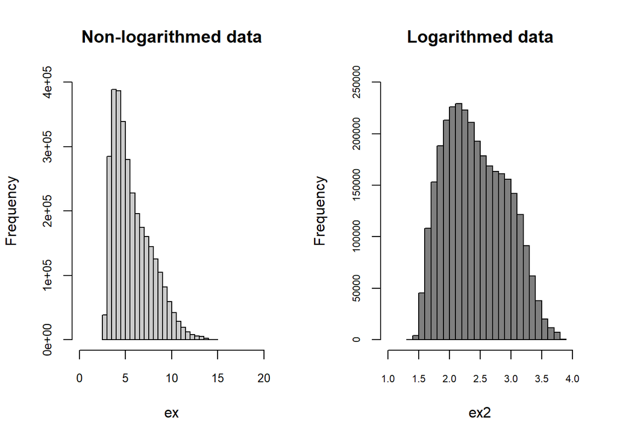

```r
par(mfrow = c(1, 2))

hist(ex,
     col = "grey80",
     xlim = c(0, 20),
     ylim = c(0, 400000),
     cex.axis = 0.8,
     main = 'Non-logarithmed data')

hist(ex2,
     col = "grey50",
     xlim = c(1, 4),
     ylim = c(0, 250000),
     cex.axis = 0.7,
     main = 'Logarithmed data')
```

The x-axis represents the gene expression values, while the y-axis represents the frequency of occurrence of each value.

The histogram on the left shows that the distribution of non-logarithmed data is skewed, with a long tail of high expression values. The histogram on the right (log2-transformed data) demonstrates more normal distribution, with a peak around 2.2.

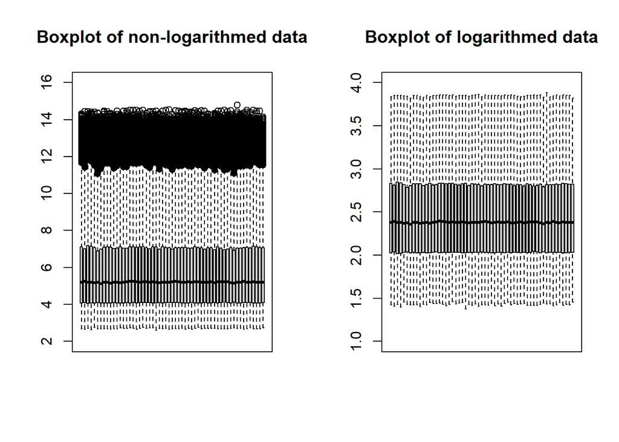

```r
par(mfrow = c(1, 2))
boxplot(ex, xaxt = "n", ylim = c(2, 16), main = 'Boxplot of non-logarithmed data')
boxplot(ex2, xaxt = "n", ylim = c(1, 4), main = 'Boxplot of logarithmed data')
```

```r
par(mfrow = c(1, 1))
ex2 <- na.omit(as.matrix(ex2))
```

# Analysis

## PCA

```r
pca <- prcomp(t(ex2))
summary(pca)
```

```
## Importance of components:
##                            PC1     PC2     PC3     PC4     PC5     PC6     PC7
## Standard deviation     11.9313 7.39587 6.82146 5.97272 5.24895 4.97817 4.38682
## Proportion of Variance  0.1904 0.07318 0.06225 0.04772 0.03686 0.03315 0.02574
## Cumulative Proportion   0.1904 0.26362 0.32587 0.37359 0.41045 0.44360 0.46934
##                            PC8     PC9   PC10    PC11   PC12    PC13    PC14
## Standard deviation     4.26721 4.02832 3.9903 3.78081 3.6781 3.60522 3.52421
## Proportion of Variance 0.02436 0.02171 0.0213 0.01912 0.0181 0.01739 0.01662
## Cumulative Proportion  0.49370 0.51541 0.5367 0.55584 0.5739 0.59132 0.60794
##                           PC15   PC16    PC17    PC18    PC19    PC20    PC21
## Standard deviation     3.48625 3.4472 3.32160 3.26228 3.21319 3.14892 3.12196
## Proportion of Variance 0.01626 0.0159 0.01476 0.01424 0.01381 0.01327 0.01304
## Cumulative Proportion  0.62420 0.6401 0.65485 0.66909 0.68290 0.69617 0.70921
##                           PC22    PC23    PC24    PC25    PC26    PC27    PC28
## Standard deviation     3.07148 3.01700 3.00323 2.97312 2.91375 2.84744 2.80432
## Proportion of Variance 0.01262 0.01218 0.01207 0.01183 0.01136 0.01085 0.01052
## Cumulative Proportion  0.72183 0.73401 0.74607 0.75790 0.76925 0.78010 0.79062
##                           PC29    PC30    PC31    PC32    PC33   PC34    PC35
## Standard deviation     2.79104 2.77017 2.73021 2.70195 2.64357 2.6360 2.58658
## Proportion of Variance 0.01042 0.01027 0.00997 0.00977 0.00935 0.0093 0.00895
## Cumulative Proportion  0.80104 0.81131 0.82128 0.83105 0.84040 0.8497 0.85864
##                           PC36    PC37    PC38    PC39    PC40    PC41    PC42
## Standard deviation     2.56611 2.53386 2.52614 2.48428 2.46560 2.43636 2.39653
## Proportion of Variance 0.00881 0.00859 0.00854 0.00826 0.00813 0.00794 0.00768
## Cumulative Proportion  0.86745 0.87604 0.88458 0.89283 0.90097 0.90891 0.91659
##                           PC43    PC44    PC45    PC46    PC47    PC48   PC49
## Standard deviation     2.37347 2.31870 2.26732 2.25931 2.25135 2.19864 2.1349
## Proportion of Variance 0.00754 0.00719 0.00688 0.00683 0.00678 0.00647 0.0061
## Cumulative Proportion  0.92413 0.93132 0.93820 0.94503 0.95181 0.95827 0.9644
##                           PC50    PC51    PC52    PC53    PC54    PC55    PC56
## Standard deviation     2.11657 2.09325 2.03962 2.03144 1.98609 1.96106 1.30194
## Proportion of Variance 0.00599 0.00586 0.00557 0.00552 0.00528 0.00514 0.00227
## Cumulative Proportion  0.97036 0.97622 0.98179 0.98731 0.99259 0.99773 1.00000
##                             PC57
## Standard deviation     3.422e-14
## Proportion of Variance 0.000e+00
## Cumulative Proportion  1.000e+00
```

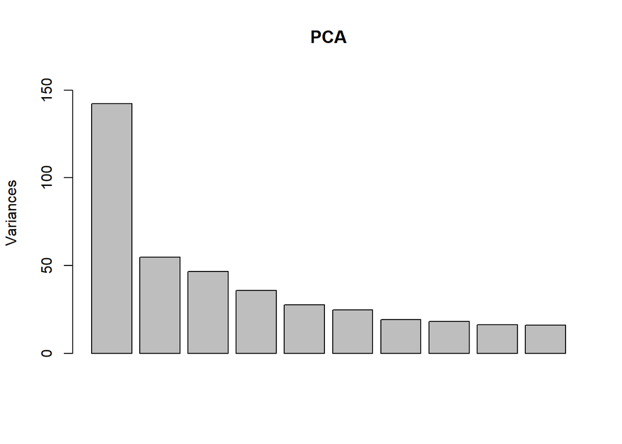

```r
screeplot(pca, ylim = c(0, 160), main = "PCA")
```

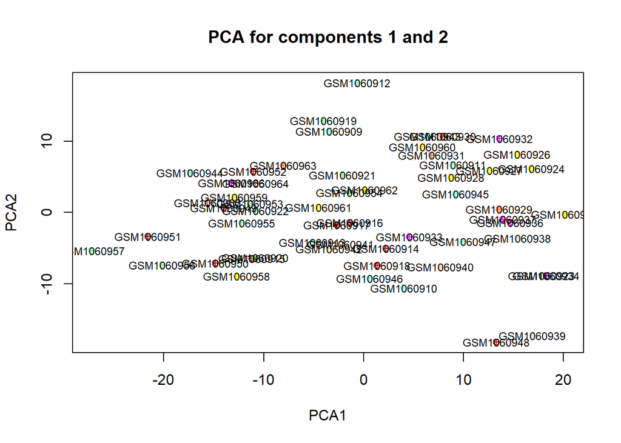

```r
grpcol <- c(rep("aquamarine", 5),
            rep("red3", 5),
            rep("lightgreen", 5),
            rep("yellow", 5),
            rep("coral", 3),
            rep("magenta", 5),
            rep("wheat", 5) )

plot(pca$x[, 1],
     pca$x[, 2],
     pch = 10,
     col = grpcol,
     type = "p",
     xlab = "PCA1",
     ylab = "PCA2",
     main = "PCA for components 1 and 2")

text(pca$x[, 1],
     pca$x[, 2],
     rownames(pca$x),
     cex = 0.75)
```

## Clustering

### Elbow plot

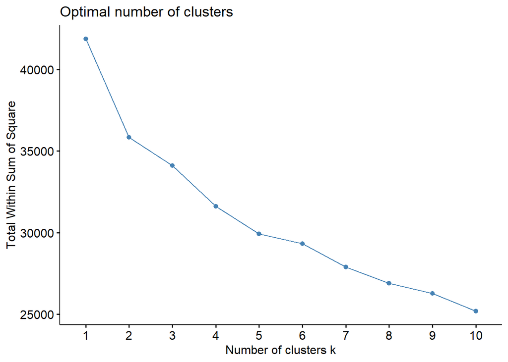

```r
fviz_nbclust(t(ex2), kmeans, method = "wss")
```

### Hierarchical clusterisation

```r
dist_matrix <- dist(t(ex2))
hc_result <- hclust(dist_matrix, method = "ave")
k <- 4
groups <- cutree(hc_result, k = k)

table(groups)
```

```
## groups
##  1  2  3  4
## 39  1 15  2
```

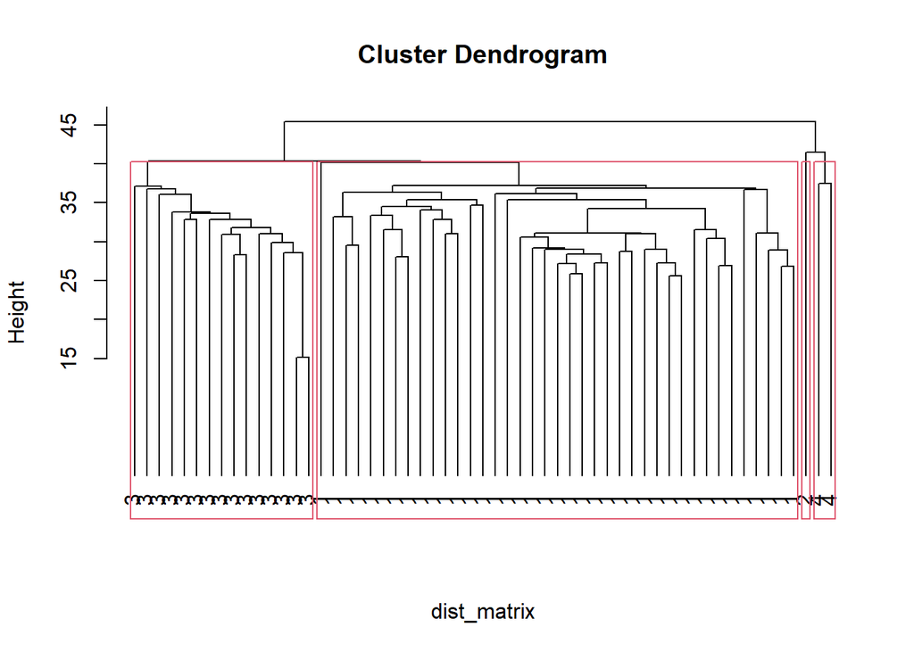

```r
plot(hc_result, hang <- -1, labels = groups, sub = "")
rect.hclust(hc_result, k = 4)
```